# Folha de Exercícios 1 — Estatística Descritiva

dplyr • tidyr • joins

08-10-2025

Recriar o dataset `alunos` tal como no enunciado (para garantir reprodutibilidade)

```r
set.seed(1234)
n <- 200
alunos <- tibble(
  id            = 1:n,
  curso         = sample(c("CC", "SI"), n, replace = TRUE, prob = c(.65, .35)),
  ano           = sample(1:3, n, replace = TRUE, prob = c(.4, .35, .25)),
  sexo          = sample(c("F", "M"), n, replace = TRUE),
  horas_estudo  = round(rlnorm(n, meanlog = log(6), sdlog = 0.5), 1),
  faltas        = pmax(0, round(rpois(n, lambda = 3) - rbinom(n, 1, .1)*3)),
  nota          = pmin(20,
                       pmax(0,
                            round( 8 +
                                     0.6 * pmin(horas_estudo, 20) -
                                     0.4 * pmin(faltas, 10) +
                                     rnorm(n, 0, 2.5), 1)))
) %>%
  mutate(
    nota = replace(nota, sample(1:n, 3), c(2, 19.5, 0)),
    horas_estudo = replace(horas_estudo, sample(1:n, 6), NA_real_)
  )
```

## 1 Exercício

Considere o tibble `alunos`.

1. Indique o tamanho amostral.
2. Classifique cada variável como categórica (nominal / ordinal) ou quantitativa (discreta / contínua).

```r
# (a) tamanho amostral (n)
n_rows <- nrow(alunos)
n_rows
```

```
## [1] 200
```

## 2 Exercício — Analise a variável `nota`

1. Calcule média, mediana, desvio - padrão, e IQR.
2. Interprete diferenças entre média e mediana (assimetria ? ).

```r
nota_stats <- alunos %>%
  summarise(
    n = sum(!is.na(nota)),
    media = mean(nota, na.rm = TRUE),
    mediana = median(nota, na.rm = TRUE),
    sd = sd(nota, na.rm = TRUE),
    IQR = IQR(nota, na.rm = TRUE)
  )
nota_stats
```

| n | media | mediana | sd | IQR |
| --- | --- | --- | --- | --- |
| 200 | 10.9645 | 10.6 | 3.579912 | 4.55 |

```r
# comparação média vs mediana e histograma rápido
nota_stats %>% mutate(diff = media - mediana)
```

| n | media | mediana | sd | IQR | diff |
| --- | --- | --- | --- | --- | --- |
| 200 | 10.9645 | 10.6 | 3.579912 | 4.55 | 0.3645 |

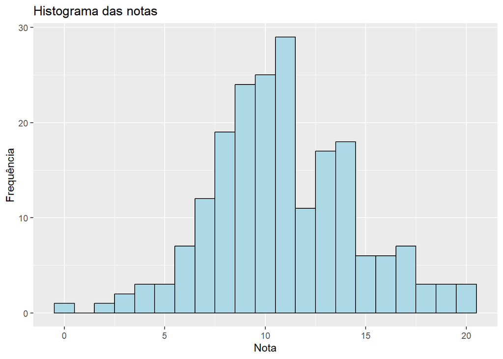

```r
ggplot(alunos, aes(x = nota)) +
  geom_histogram(binwidth = 1,
                 fill = "lightblue",
                 color = "black") +
  labs(title = "Histograma das notas", x = "Nota", y = "Frequência")
```

## 3 Exercício — Outliers (Tukey)

1. Determine barreiras de Tukey:Q1 - 1.5×IQR e Q3 + 1.5×IQR para `nota`.
2. Liste observações classificadas como outliers.
3. Faça um boxplot e anote a presença de outliers.

### 3.1 RESPOSTA (a,b,c)

```r
qs <- quantile(alunos$nota, probs = c(0.25, 0.75), na.rm = TRUE)
Q1 <- qs[1]
Q3 <- qs[2]
IQR_nota <- Q3 - Q1
lower_bound <- Q1 - 1.5 * IQR_nota
upper_bound <- Q3 + 1.5 * IQR_nota
list(
  Q1 = Q1,
  Q3 = Q3,
  IQR = IQR_nota,
  lower = lower_bound,
  upper = upper_bound
)
```

```
## $Q1
##  25%
## 8.75
##
## $Q3
##  75%
## 13.3
##
## $IQR
##  75%
## 4.55
##
## $lower
##   25%
## 1.925
##
## $upper
##    75%
## 20.125
```

```r
outliers_vals <- alunos %>%
  mutate(is_out = if_else(nota < lower_bound |
                            nota > upper_bound, TRUE, FALSE)) %>%
  filter(is_out) %>%
  arrange(nota) %>%
  select(id, curso, sexo, horas_estudo, faltas, nota)
outliers_vals
```

| id | curso | sexo | horas_estudo | faltas | nota |
| --- | --- | --- | --- | --- | --- |
| 186 | CC | M | 29.7 | 2 | 0 |

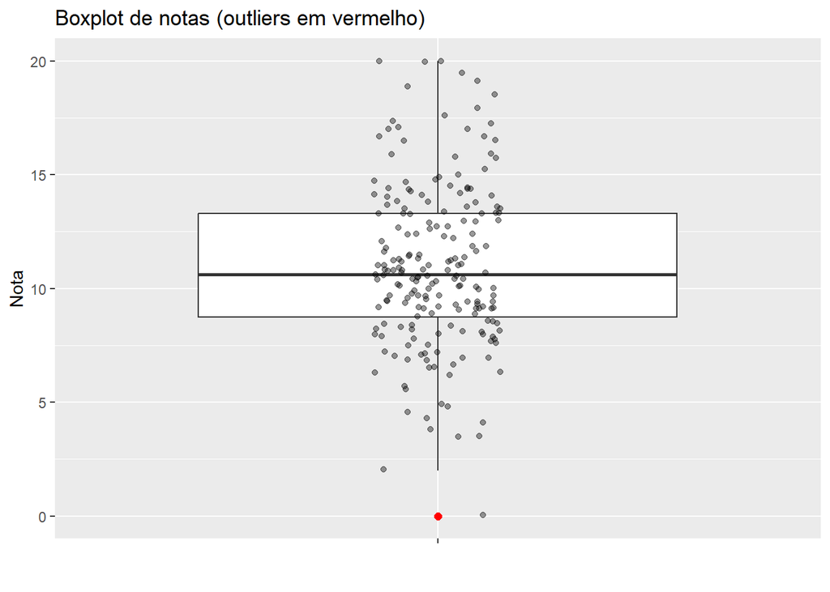

```r
ggplot(alunos, aes(x = "", y = nota)) +
  geom_boxplot(outlier.colour = "red", outlier.size = 2) +
  geom_jitter(width = 0.1, alpha = 0.4) +
  labs(title = "Boxplot de notas (outliers em vermelho)", x = "", y = "Nota")
```

## 4 Exercício — Histograma + densidade para `nota`

1. Construa um histograma comente a escolha de `binwidth`.
2. Sobreponha uma densidade (`geom_density`).

### 4.1 RESPOSTA 4(a,b)

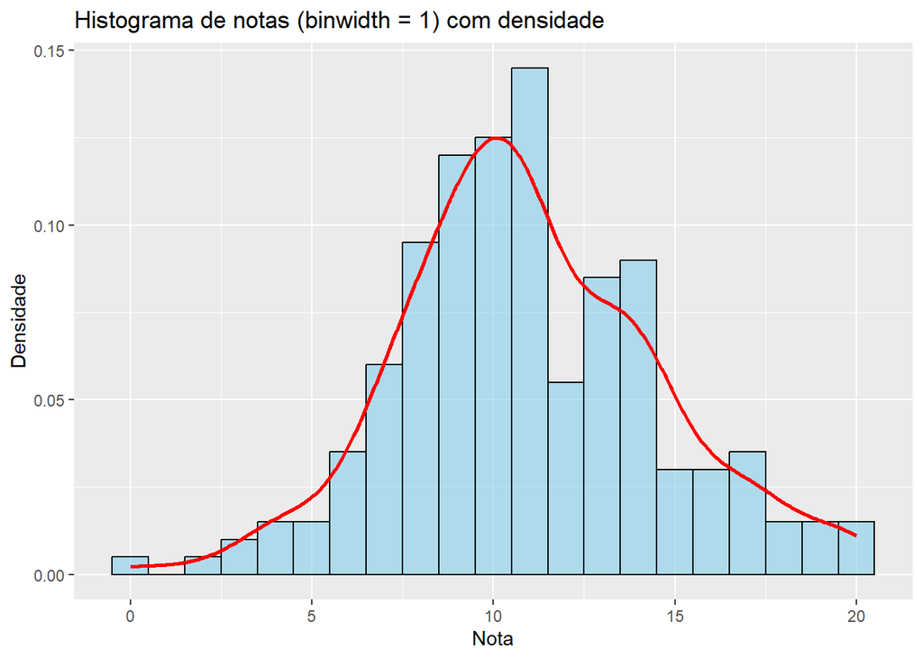

```r
# histograma com densidade sobreposta
binw <- 1
p_hist_dens <- ggplot(alunos, aes(x = nota)) +
  geom_histogram(
    aes(y = ..density..),
    binwidth = binw,
    fill = "skyblue",
    color = "black",
    alpha = 0.6
  ) +
  geom_density(size = 1, color = "red") +
  labs(
    title = paste0("Histograma de notas (binwidth = ", binw, ") com densidade"),
    x = "Nota",
    y = "Densidade"
  )

p_hist_dens
```

## 5 Exercício — Comparar `nota` entre `curso` e `sexo`

1. Crie boxplots lado a lado por curso comente diferenças de centro e dispersão.
2. Produza uma tabela - resumo por curso e sexo (n, média, mediana, IQR).
3. Discuta se diferenças podem ser atribuídas a distribuições ou a outliers.

### 5.1 RESPOSTA 5(a,b,c)

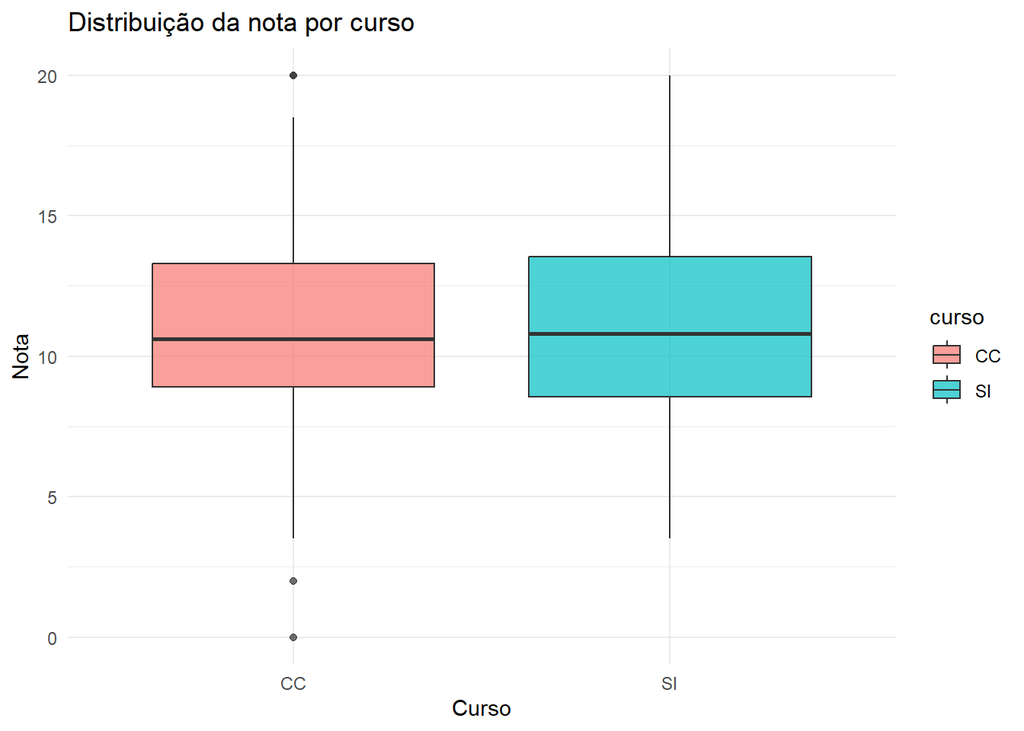

```r
# boxplots por curso
ggplot(alunos, aes(x = curso, y = nota, fill = curso)) +
  geom_boxplot(alpha = 0.7) +
  labs(title = "Distribuição da nota por curso", x = "Curso", y = "Nota") +
  theme_minimal()
```

```r
resumo_curso_sexo <- alunos %>%
  group_by(curso, sexo) %>%
  summarise(
    n = n(),
    media = mean(nota, na.rm = TRUE),
    mediana = median(nota, na.rm = TRUE),
    IQR = IQR(nota, na.rm = TRUE)
  ) %>%
  arrange(curso, sexo)
resumo_curso_sexo
```

| curso | sexo | n | media | mediana | IQR |
| --- | --- | --- | --- | --- | --- |
| CC | F | 75 | 10.91600 | 10.80 | 4.25 |
| CC | M | 66 | 10.77879 | 10.40 | 4.60 |
| SI | F | 31 | 11.35161 | 10.60 | 4.40 |
| SI | M | 28 | 11.10357 | 11.05 | 5.45 |

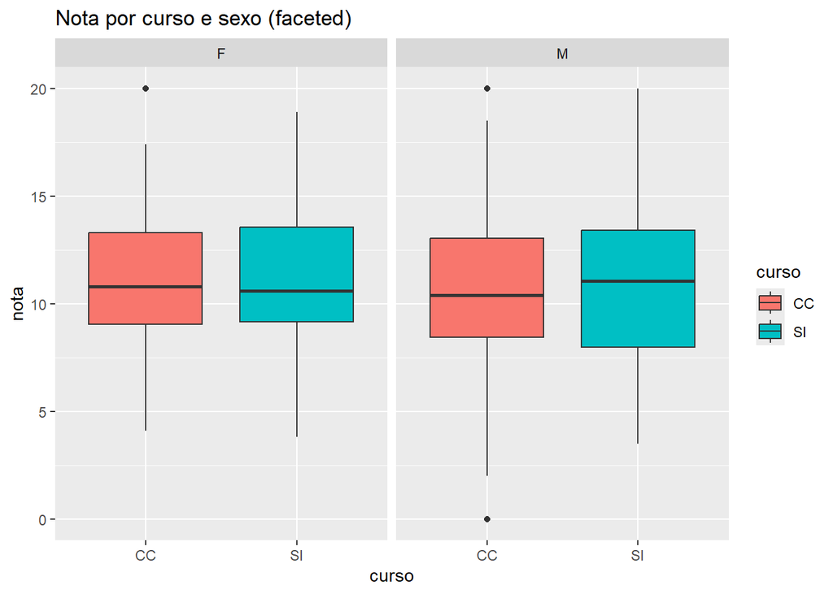

```r
# gráfico com facet por sexo para visualizar diferenças
ggplot(alunos, aes(x = curso, y = nota, fill = curso)) +
  geom_boxplot() +
  facet_wrap( ~ sexo) +
  labs(title = "Nota por curso e sexo (faceted)")
```

## 6 Exercício — Horas de estudo vs nota

1. Gráfico de dispersão trate os NAs.
2. Calcule correlação de Pearson e Spearman comente.

### 6.1 RESPOSTA 6(a,b)

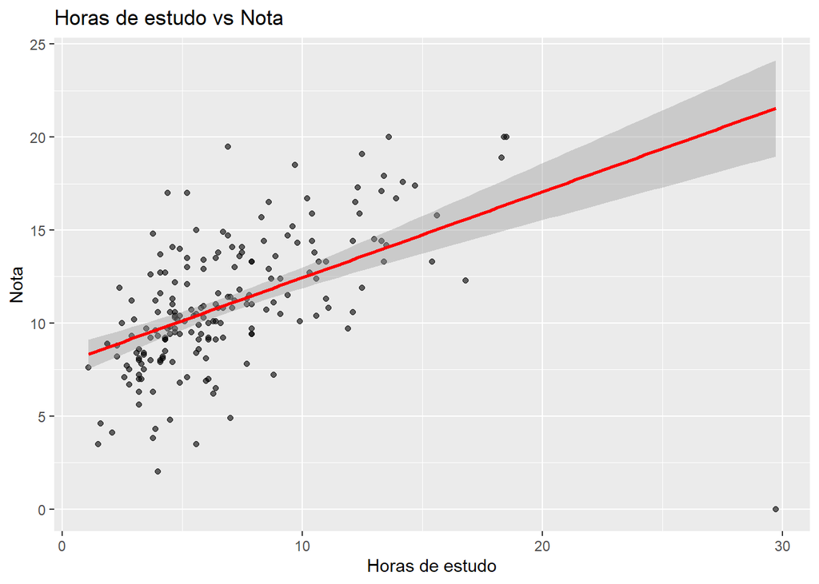

```r
alunos_clean <- alunos %>% filter(!is.na(horas_estudo))

ggplot(alunos_clean, aes(x = horas_estudo, y = nota)) +
  geom_point(alpha = 0.6) +
  geom_smooth(method = "lm",
              se = TRUE,
              color = "red") +
  labs(title = "Horas de estudo vs Nota", x = "Horas de estudo", y = "Nota")
```

```r
# correlações
pearson <- cor(alunos_clean$horas_estudo, alunos_clean$nota, method = "pearson")
spearman <- cor(alunos_clean$horas_estudo, alunos_clean$nota, method = "spearman")
list(pearson = pearson, spearman = spearman)
```

```
## $pearson
## [1] 0.5075115
##
## $spearman
## [1] 0.6372695
```

## 7 Exercício — Transformação log

1. Observe a distribuição de `horas_estudo` (histograma / densidade).
2. Aplique transformação `log` a `horas_estudo` e volte a comparar com `nota`.
3. Comente o efeito da transformação na linearidade e heterocedasticidade.

### 7.1 RESPOSTA 7(a,b,c)

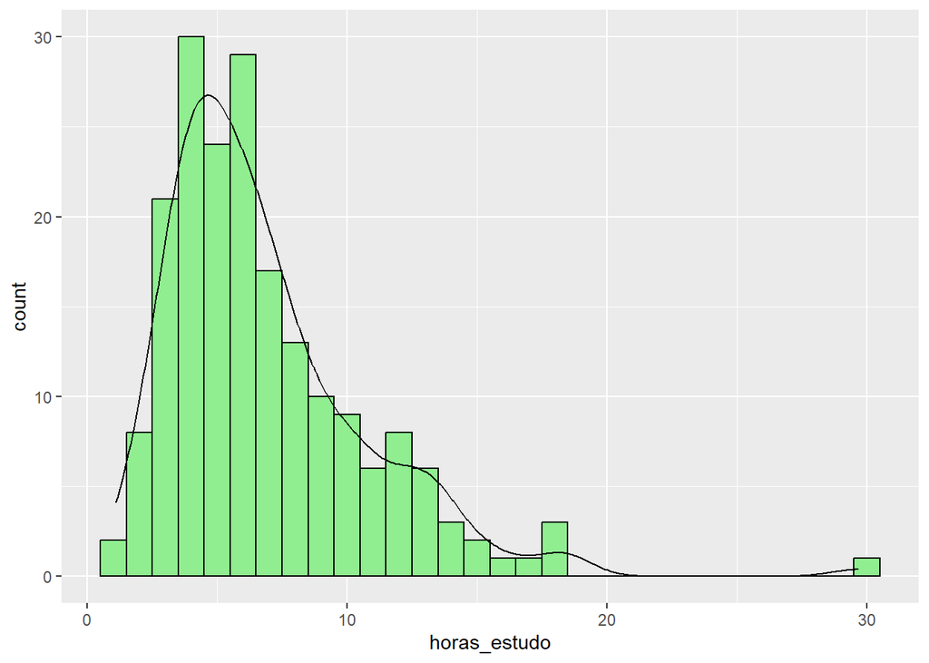

```r
# distribuição original
alunos %>% filter(!is.na(horas_estudo)) %>%
  ggplot(aes(x = horas_estudo)) +
  geom_histogram(
    binwidth = 1,
    fill = "lightgreen",
    color = "black"
  ) +
  geom_density(aes(y = ..count..), inherit.aes = TRUE, alpha = 0.2)
```

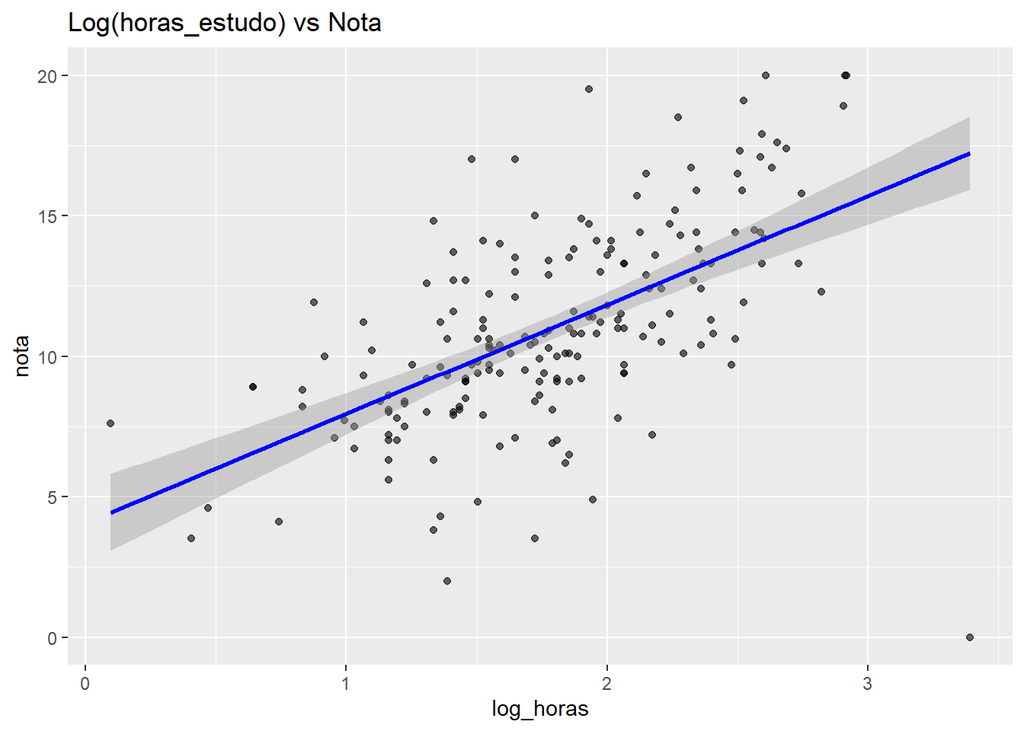

```r
alunos %>% filter(!is.na(horas_estudo)) %>%
  mutate(log_horas = log(horas_estudo)) %>%
  ggplot(aes(x = log_horas, y = nota)) +
  geom_point(alpha = 0.6) +
  geom_smooth(method = "lm",
              se = TRUE,
              color = "blue") +
  labs(title = "Log(horas_estudo) vs Nota")
```

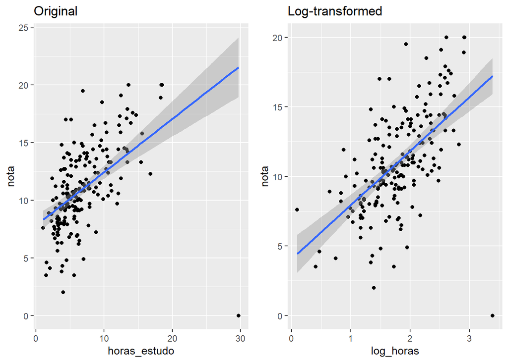

```r
# comparar linearidade/heterocedasticidade visualmente: lado a lado
p1 <- alunos %>% filter(!is.na(horas_estudo)) %>% ggplot(aes(x = horas_estudo, y = nota)) + geom_point() + geom_smooth(method = "lm") + labs(title = "Original")

p2 <- alunos %>% filter(!is.na(horas_estudo)) %>% mutate(log_horas = log(horas_estudo)) %>% ggplot(aes(x = log_horas, y = nota)) + geom_point() + geom_smooth(method = "lm") + labs(title = "Log-transformed")

library(gridExtra)
grid.arrange(p1, p2, ncol = 2)
```